# Calibration and discrimination

A worked example at the bus stop

Doug Manuel

EPI 6101 An Introduction to Machine Learning

13 October 2026

## The bus stop

[figure not shown]

Agnes, Beatrice, Clara, Dorothy and Batman waiting at a bus stop

Illustration generated with Gemini, prompted by Doug Manuel. Batman is the property of DC Comics.

## From picture to data

```r
riders <- data.frame(
  rider     = c("Agnes", "Beatrice", "Clara", "Dorothy", "Batman"),
  age       = c(35, 80, 85, 80, 40),
  cane      = c(0, 0, 1, 0, 0),
  superhero = c(0, 0, 0, 0, 1),
  boarded   = c(0, 1, 1, 1, 0), # got on the first bus
  minutes   = c(35, 15.5, 15, 15.25, 35.25) # after 8:00
)
```

The first bus has room for three. Observed: 3 of 5 boarded, or **0.60**.

`age`, `cane`, `superhero`: the **predictors** (in machine learning, *features*). `boarded`: the **outcome** (*label* or *target*).

## Two models

$$\text{logit}(p) = \beta_0 + \beta_1 \tfrac{\text{age} - 60}{10} + \beta_2\,\text{cane} + \beta_3\,\text{superhero}$$

$p$: probability of boarding the first bus. $\text{logit}(p) = \log\frac{p}{1 - p}$, the log-odds. Each $\beta$ is a coefficient (*weight*; $\beta_0$ is the *bias*). `plogis()` turns log-odds back into a probability (the *sigmoid* function).

|  | Model A | Model B |
| --- | --- | --- |
| $\beta_0$ intercept | 2.0 | 0.0 |
| $\beta_1$ age | 0.1 | 0.1 |
| $\beta_2$ cane | 1.0 | 0.0 |
| $\beta_3$ superhero | −1.0 | 2.5 |

| `rider` | `boarded` | `model_a` | `model_b` |
| --- | --- | --- | --- |
| Agnes | 0 | 0.85 | 0.44 |
| Beatrice | 1 | 0.90 | 0.55 |
| Clara | 1 | 0.96 | 0.56 |
| Dorothy | 1 | 0.90 | 0.55 |
| Batman | 0 | 0.69 | 0.91 |

**Which model is better?**

### Discrimination

**Who** gets on the bus first?

How well the predictions differentiate between individuals with and without the outcome.

### Calibration

**When** do they get on the bus?

Agreement between observed outcomes and estimated values from the model.

TRIPOD+AI. *BMJ* 2024;385. doi:10.1136/bmj-2023-078378

# Discrimination

## The c statistic counts pairs

Pair each rider who boarded with each rider who did not: 3 × 2 = 6 pairs. The c statistic is also called the concordance statistic, and in machine learning the *AUC*.

A pair is **concordant** when the model gives the rider who boarded the higher probability.

$$c = \frac{\text{concordant pairs} + \tfrac{1}{2}\,\text{tied pairs}}{\text{all pairs}}$$

- $c = 1$: perfect ranking
- $c = 0.5$: no better than a coin toss

## Model A ranks perfectly; Model B is a coin toss

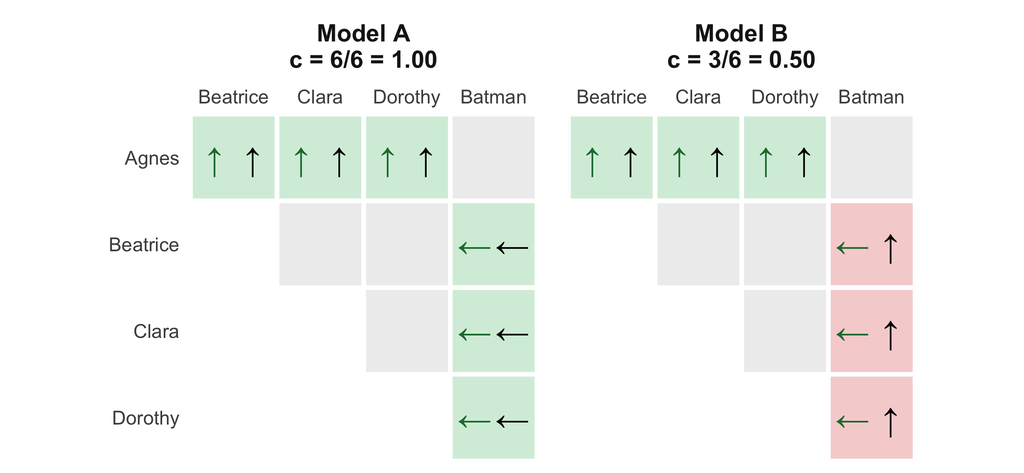

**Green arrow**: who got on. **Black arrow**: the model’s pick (higher probability). Arrows point at the rider: ↑ column, ← row. Grey: both got on, or both waited, so not compared.

## Worked by hand

Each pair scores 1 if the model ranks the rider who boarded higher, ½ if tied, 0 if not. Then average.

$$c_A = \frac{1 + 1 + 1 + 1 + 1 + 1}{6}
= \frac{6}{6}
= {\color{#1b7a3a}\mathbf{1.00}}$$

$$c_B = \frac{1 + 1 + 1 + 0 + 0 + 0}{6}
= \frac{3}{6}
= {\color{#b03030}\mathbf{0.50}}$$

## The same count in R

```r
p <- riders$model_b # try model_a too
pairs <- expand.grid(
  boarded = which(riders$boarded == 1),
  waited = which(riders$boarded == 0)
)
better <- p[pairs$boarded] > p[pairs$waited]
tied <- p[pairs$boarded] == p[pairs$waited]
mean(better + 0.5 * tied)
```

```
[1] 0.5
```

## From pairs to a curve: the ROC

Pick a threshold $t$ and predict “boards” for anyone with $p \ge t$. Every threshold gives a different yes/no prediction:

$$\text{sensitivity} = \frac{TP}{\text{boarded } (3)}
\qquad
1 - \text{specificity} = \frac{FP}{\text{waited } (2)}$$

Model B. $TP$, true positives: predicted to board, and did. $FP$, false positives: predicted to board, but waited. Machine learning calls sensitivity *recall* or the *true positive rate*, and 1 − specificity the *false positive rate*.

| Predict boards if p | TP | FP | Sensitivity | 1 − specificity |
| --- | --- | --- | --- | --- |
| none | 0 | 0 | 0.00 | 0.00 |
| ≥ 0.91 | 0 | 1 | 0.00 | 0.50 |
| ≥ 0.56 | 1 | 1 | 0.33 | 0.50 |
| ≥ 0.55 | 3 | 1 | 1.00 | 0.50 |
| ≥ 0.44 | 3 | 2 | 1.00 | 1.00 |

## ROC curves for Models A and B

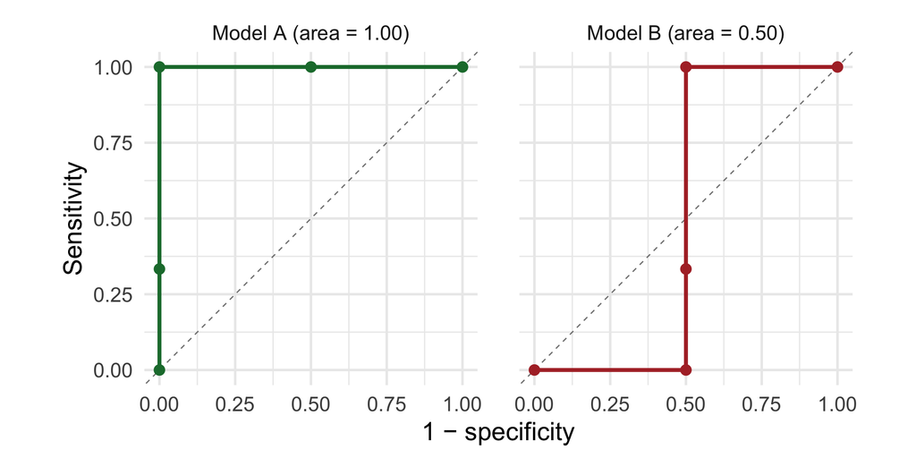

The dashed diagonal is a coin toss.

## The area under the curve is the c statistic

Add up the trapezoids: each step adds width × average height, $\Delta x \times \tfrac{1}{2}(\text{sens}_{k-1} + \text{sens}_k)$.

$\Delta x$: the step in 1 − specificity. $\text{sens}_k$: sensitivity at threshold $k$.

$$\text{area}_B = 0.00 + 0.00 + 0.00 + 0.50 = {\color{#b03030}\mathbf{0.50}}$$

The same number as counting pairs: $c_B$ = 0.50.

```r
# rb: the ROC table from two slides back
rb <- roc_points(riders$model_b, riders$boarded)
dx <- diff(rb$fpr)
height <- (head(rb$tpr, -1) + tail(rb$tpr, -1)) / 2
sum(dx * height)
```

```
[1] 0.5
```

## A word of caution about the ROC

- The ROC curve is everywhere in machine learning. In medicine it is debated.
- It summarises ranking over **every** threshold, including thresholds nobody would use.
- It ignores calibration. Model A has c = 1.00 but predicts 0.86 on average when 0.60 boarded.
- It ignores the costs of false positives and false negatives at the threshold you actually choose.
- Report it alongside a calibration plot, and a decision-focused measure such as net benefit (the good done by true positives minus the harm of false positives, at the threshold you use).

# Calibration

## Calibration-in-the-large: compare the averages

$$O = \frac{1}{N}\sum_{i=1}^{N} y_i \qquad E = \frac{1}{N}\sum_{i=1}^{N} p_i$$

**O**, observed: the share who boarded. **E**, expected: the average predicted probability. $N$ = 5 riders. $y_i$: rider $i$’s `boarded` (1 = got on, 0 = waited). $p_i$: rider $i$’s predicted probability (`model_a` or `model_b`).

$$O = \frac{0 + 1 + 1 + 1 + 0}{5} = 0.60$$

$$E_A = \frac{0.85 + 0.90 + 0.96 + 0.90 + 0.69}{5} = \frac{4.30}{5} = 0.86$$

$$E_B = \frac{0.44 + 0.55 + 0.56 + 0.55 + 0.91}{5} = \frac{3.01}{5} = 0.60$$

## Observed against predicted

$$\text{O/E}_A = \frac{0.60}{0.86} = 0.70
\qquad
\text{O/E}_B = \frac{0.60}{0.60} = 1.00$$

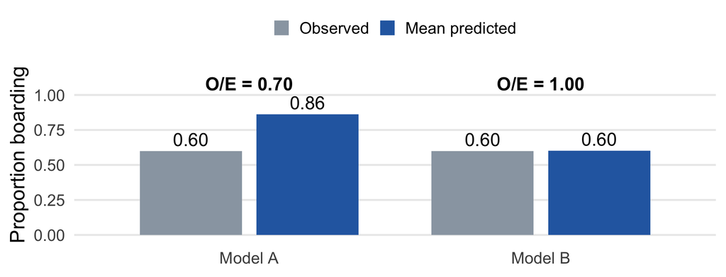

Model A over-predicts by 43%: “much higher” (more than 20%) on the scale used to judge the Framingham equations in Canada.

## Brier score: average squared error

$$\text{Brier} = \frac{1}{N}\sum_{i=1}^{N} (p_i - y_i)^2$$

$p_i$: predicted probability (`model_a`, `model_b`). $y_i$: `boarded`, 1 or 0. $N$ = 5 riders. In machine learning, the Brier score is the *mean squared error* of the probabilities.

| `rider` | `boarded` | Model A | Model B |
| --- | --- | --- | --- |
| Agnes | 0 | (0.85 − 0)² = 0.72 | (0.44 − 0)² = 0.19 |
| Beatrice | 1 | (0.90 − 1)² = 0.01 | (0.55 − 1)² = 0.20 |
| Clara | 1 | (0.96 − 1)² = 0.00 | (0.56 − 1)² = 0.19 |
| Dorothy | 1 | (0.90 − 1)² = 0.01 | (0.55 − 1)² = 0.20 |
| Batman | 0 | (0.69 − 0)² = 0.48 | (0.91 − 0)² = 0.83 |
|  |  | **Brier = 1.22 / 5 = 0.24** | **Brier = 1.61 / 5 = 0.32** |

## Picturing the Brier score

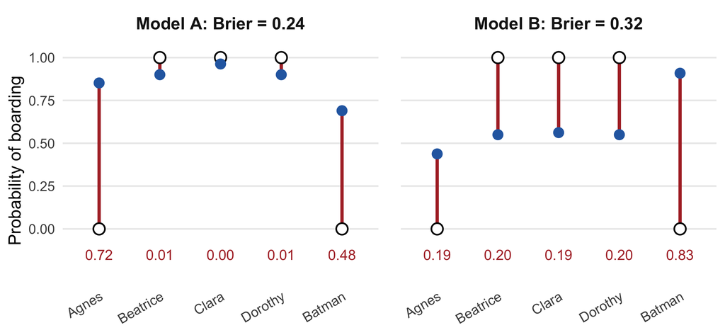

**Blue**: the prediction. **White**: what happened (1 = boarded, 0 = waited). The red line is the error; the number under each rider is its square. Average the squares.

## The Brier score mixes both problems

**Model A**

Perfect ranking (c = 1.00), yet a Brier score of 0.24, no better than predicting 0.60 for everyone

**Model B**

Right on average (O/E = 1.00), yet a Brier score of 0.32, worse still

One number cannot tell you *which* problem a model has. Report discrimination and calibration separately (TRIPOD+AI).

## F1 and accuracy mix them too

Machine learning often scores a model at a threshold: predict “boards” if $p \ge 0.50$.

|  | Model A | Model B |
| --- | --- | --- |
| Precision (PPV) = TP / (TP + FP) | 3 / 5 = 0.60 | 3 / 4 = 0.75 |
| Recall (sensitivity) = TP / (TP + FN) | 3 / 3 = 1.00 | 3 / 3 = 1.00 |
| **F1** | **0.75** | **0.86** |
| Accuracy = (TP + TN) / N | 0.60 | 0.80 |
| c statistic | 1.00 | 0.50 |
| O/E | 0.70 | 1.00 |

F1 $= \dfrac{2 \times \text{precision} \times \text{recall}}{\text{precision} + \text{recall}}$. Precision is the positive predictive value (PPV): the share of predicted boarders who boarded. Recall is sensitivity. TN, true negatives: predicted to wait, and did.

By F1, the coin-toss model wins.

# Recalibration

## Recalibrate Model A: shift the log-odds

$$\text{logit}(p_i^{*}) = \text{logit}(p_i) + a$$

Estimate $a$ with a logistic regression that has $\text{logit}(p_i)$ as an offset: $a$ = −1.58

$p_i^{*}$: rider $i$’s recalibrated probability. $a$: one shift, the same for every rider. An offset keeps $\text{logit}(p_i)$ fixed, so only $a$ is estimated.

|  | Model A | Model A recalibrated |
| --- | --- | --- |
| Mean predicted | 0.86 | 0.60 |
| c statistic | 1.00 | 1.00 |
| Brier score | 0.24 | 0.13 |

## Recalibration cannot fix discrimination

[figure not shown]

Same constant added to every log-odds: same **order**, same arrows. Model A can be **repaired**; Model B needs **new coefficients**, a new model.

# When do they get on?

## Boarding times

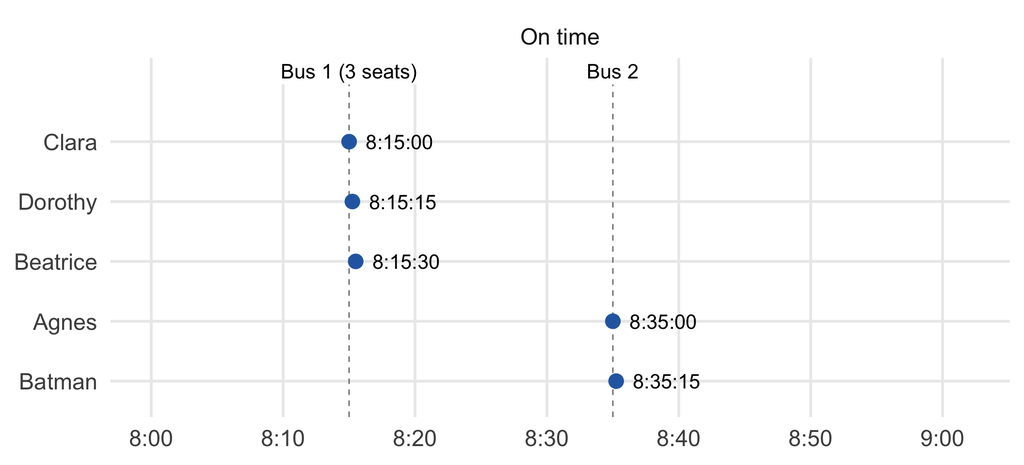

Everyone reaches the stop at 8:00. Order of boarding: Clara, Dorothy, Beatrice, Agnes, Batman.

## A model for time

$$h_i(t) = h_0(t)\,\exp(\text{lp}_i)$$

$$\text{lp}_i = 0.1\,\tfrac{\text{age} - 60}{10} + 1.0\,\text{cane} - 1.0\,\text{superhero}$$

$$S_i(t) = S_0(t)^{\exp(\text{lp}_i)} \qquad P_i(\text{on a bus by } t) = 1 - S_i(t)$$

$\text{lp}_i$: the **linear predictor**, the weighted sum of rider $i$’s predictors (Model A’s slopes, no intercept). $h_i(t)$: rider $i$’s hazard, the chance of boarding in the next moment if still waiting. $h_0(t)$: the baseline hazard. $\exp(\text{lp}_i)$: the hazard ratio. $S_i(t)$: the chance rider $i$ is still waiting at time $t$. $S_0(t)$: the **baseline survival**, the chance a rider with $\text{lp} = 0$ is still waiting at $t$.

The same slopes as Model A, but **no intercept**: the baseline takes its place.

## Predictions for 8:20

$S_0(\text{8:20}) = 0.41$, set so the average prediction matches the on-time day, so $P_i(\text{on a bus by 8:20}) = 1 - 0.41^{\exp(\text{lp}_i)}$.

| `rider` | lp | exp(lp) | On a bus by 8:20 |
| --- | --- | --- | --- |
| Agnes | −0.25 | 0.78 | 0.50 |
| Beatrice | 0.20 | 1.22 | 0.66 |
| Clara | 1.25 | 3.49 | 0.96 |
| Dorothy | 0.20 | 1.22 | 0.66 |
| Batman | −1.20 | 0.30 | 0.24 |

Clara: $1 - 0.41^{3.49} = 0.96$

## With time: who got on first?

[figure not shown]

**Green arrow**: who got on first. **Black arrow**: the model’s pick. Everyone boarded at a different time, so no cell is grey.

## With time, every pair counts

Any two riders who boarded at different times make a pair: 10 pairs, not 6. A pair is concordant when the rider who boarded **first** had the higher predicted probability.

$$c_A = \frac{1 + 1 + 1 + 1 + 1 + 0.5 + 1 + 1 + 1 + 1}{10}
= {\color{#1b7a3a}\mathbf{0.95}}$$

$$c_B = \frac{1 + 1 + 1 + 0 + 1 + 0.5 + 0 + 1 + 0 + 0}{10}
= {\color{#b03030}\mathbf{0.55}}$$

Model A goes from 1.00 to 0.95 and Model B from 0.50 to 0.55: time also checks the order **within** the riders who boarded and within those who waited, and a tie there scores ½.

## The same count in R, with time

```r
library(survival)
riders$event <- 1 # everyone boards eventually
fit <- concordance(
  Surv(minutes, event) ~ model_b,
  data = riders,
  reverse = TRUE # higher p = earlier boarding
)
fit$concordance
```

```
[1] 0.55
```

## Rank order: the same pairs, without the clock

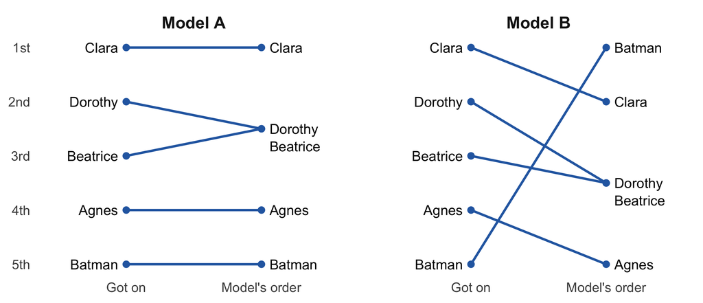

Left: the order they got on. Right: the order the model predicted. **Each crossing is a pair the model got backwards**; lines that meet are a tie.

## Somers’ D: right minus wrong

$$D = \frac{\text{concordant} - \text{discordant}}{\text{all pairs}} = 2c - 1$$

$$D_A = \frac{9 - 0}{10} = 0.90
\qquad
D_B = \frac{5 - 4}{10} = 0.10$$

|  | Coin toss | Perfect | Model A | Model B |
| --- | --- | --- | --- | --- |
| c statistic (AUC) | 0.50 | 1.00 | 0.95 | 0.55 |
| Somers’ D = 2c − 1 | 0.00 | 1.00 | 0.90 | 0.10 |

Ties count in “all pairs” but neither add nor subtract. In machine learning, 2 × AUC − 1 is called the **Gini coefficient**: the same quantity. A ranking has no probabilities, so there is nothing to calibrate.

## The bus is 15 minutes late

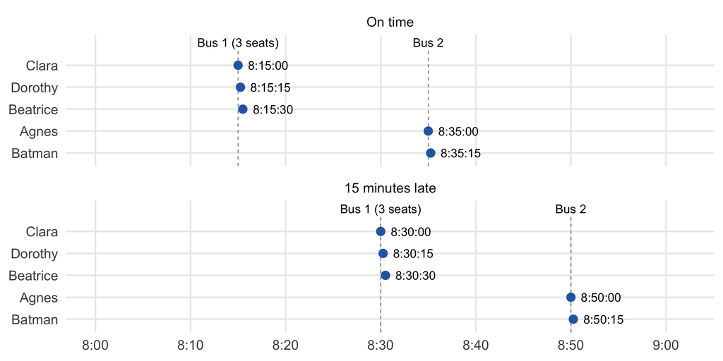

Same riders, same order. Every boarding is 15 minutes later.

## Same ranking, broken calibration

The Cox model’s predictions for 8:20 do not change: same riders, same order.

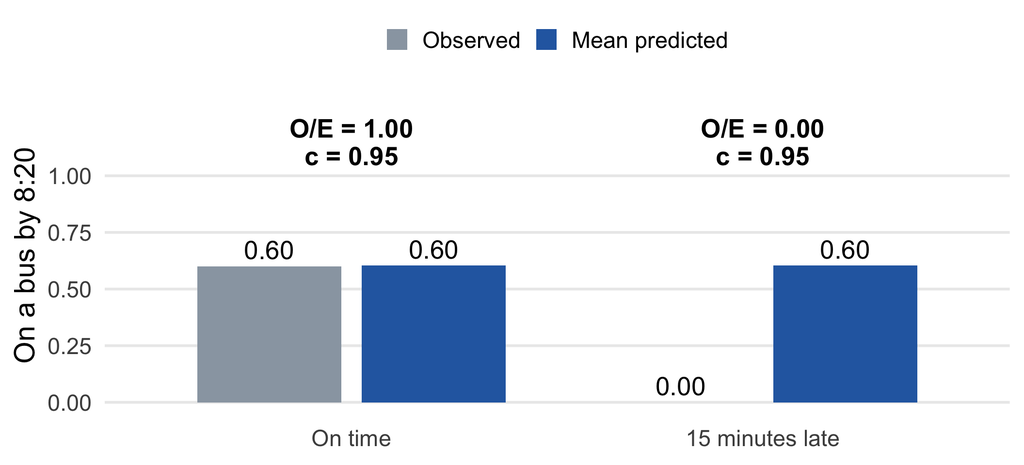

Discrimination is about **order**, so a late bus cannot change it. Calibration is about the **time to event**.

## The baseline is the timetable

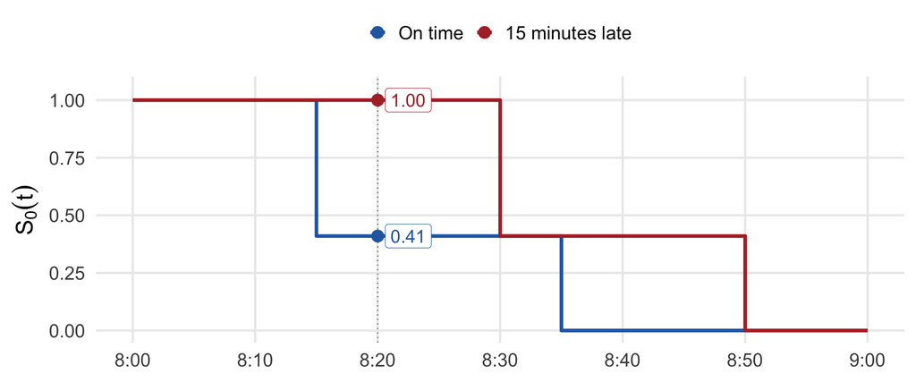

Before a bus comes nobody can board, so $S_0(t) = 1$; each bus is a step down. A model that takes $S_0$ from the published timetable is calibrated only when the buses run on time.

## Calibration depends on the time horizon

| Observed | On time | 15 minutes late |
| --- | --- | --- |
| On board by 8:20 | 0.60 | 0.00 |
| On board by 8:40 | 1.00 | 0.60 |

The late bus changes the **baseline**, $S_0(t)$. On the late day nobody is on a bus by 8:20, so $S_0(\text{8:20})$ should be 1.00, not 0.41.

The linear predictor $\text{lp}_i$, which sets the order, is untouched. Recalibrating means re-estimating $S_0(t)$ for the new day, just as we shifted the intercept for Model A.

## Why calibration is harder than discrimination

- Age, cane and superhero status tell us **who gets on before whom**: the order
- Nothing in our data says **when the bus comes**. That is the baseline, $S_0(t)$: the timetable, the traffic, the day
- Discrimination needs only the order, so it travels from one bus stop to another
- Calibration needs the order **and** the baseline, so it has to be checked, and often re-estimated, wherever the model is used

# More riders

## A calibration plot needs many riders

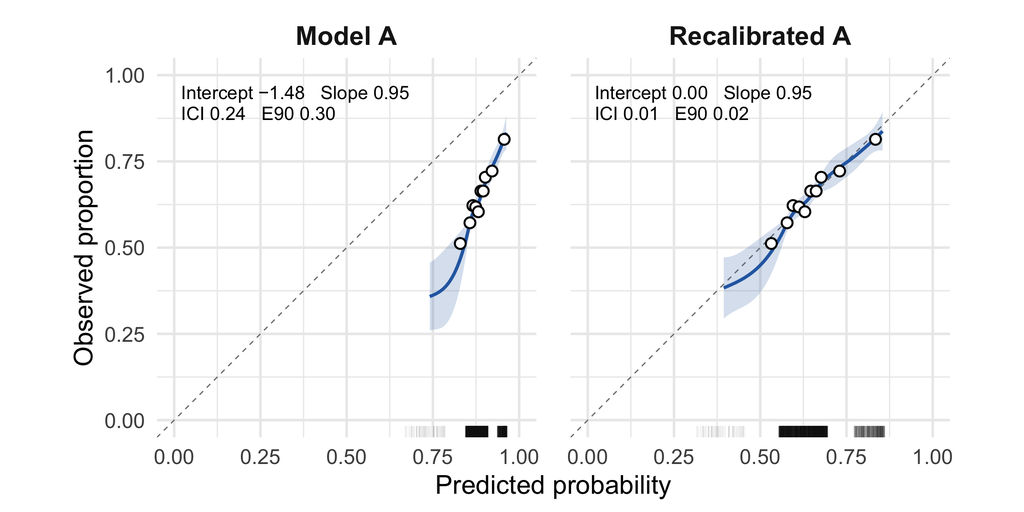

5,000 simulated riders scored with Model A’s formula. **Line**: LOESS curve with 95% band. **Circles**: tenths of predicted risk. **Ticks**: where predictions fall. **Dashed**: perfect calibration.

## Reading the plot, and how we recalibrated

- **Calibration intercept**: are predictions too high or too low overall? Ideal 0. Model A: −1.48, too high
- **Calibration slope**: is the spread right? Ideal 1. Below 1, predictions are too extreme (common after overfitting). Model A: 0.95, about right
- Only the intercept is wrong, so we shift every rider’s log-odds by the same amount:

```r
fit <- glm(boarded ~ 1, offset = qlogis(model_a),
  family = binomial, data = sim)
sim$model_a_recal <- plogis(qlogis(sim$model_a) + coef(fit))
```

`qlogis()`: probability to log-odds; `plogis()`: back again. The offset keeps each rider’s log-odds fixed, so only the shift $a$ = −1.48 is estimated. If the slope were off too, fit $\text{logit}(p^{*}) = a + b\,\text{logit}(p)$ instead; machine learning calls this *Platt scaling*.

## Summary measures: ICI, E50 and E90

How far is the curve from the diagonal, on average and at worst?

$$\text{ICI} = \frac{1}{N}\sum_{i=1}^{N} \left| p_i - \hat{y}_i \right|$$

$\hat{y}_i$: the LOESS curve’s observed proportion at rider $i$’s predicted probability. E50 and E90: the median and the 90th percentile of $|p_i - \hat{y}_i|$.

|  | Model A | Recalibrated A |
| --- | --- | --- |
| Calibration intercept (ideal 0) | −1.48 | 0.00 |
| Calibration slope (ideal 1) | 0.95 | 0.95 |
| ICI | 0.24 | 0.01 |
| E50 | 0.25 | 0.01 |
| E90 | 0.30 | 0.02 |

Austin and Steyerberg. *Stat Med* 2019;38:4051–65. doi:10.1002/sim.8281

## A ladder of recalibration

| Step | Method | What changes | Bus-stop problem |
| --- | --- | --- | --- |
| 1 | Intercept (in the large) | One shift | Model A over-predicts |
| 1 | Baseline (survival) | $S_0(t)$ | The bus is late |
| 2 | Intercept and slope (*Platt*) | Shift and stretch | Model C is overconfident |
| 3 | Isotonic regression | Any increasing curve | An irregular curve |
| 4 | Revision | Some coefficients | Model B’s superhero sign |
| 5 | Refit | Everything | Nothing else works |

Climb only as far as you need: each step needs more data and can overfit the recalibration itself. Steps 1 to 3 keep the order of riders, so they cannot change discrimination; steps 4 and 5 change the model itself.

## Step 2: intercept and slope

Model C was developed at a small, unusual bus stop. Same predictors, but the coefficients are too large: $\text{logit}(p) = 1.5 + 0.25\,\tfrac{\text{age} - 60}{10} + 2.5\,\text{cane} − 2.5\,\text{superhero}$

$$\text{logit}(p^{*}) = a + b\,\text{logit}(p) \qquad a = −0.04, \quad b = 0.38$$

$b = 1$ is intercept-only recalibration (step 1). $b < 1$: predictions are too extreme, so they are pulled toward the middle. $b > 1$: too timid, so they are spread out. Machine learning calls this *Platt scaling*.

```r
fit <- glm(boarded ~ qlogis(model_c), family = binomial, data = sim)
sim$model_c_recal <- predict(fit, type = "response")
```

## Model C at the bus stop

| `rider` | `boarded` | Model C | Recalibrated C |
| --- | --- | --- | --- |
| Agnes | 0 | 0.71 | 0.57 |
| Beatrice | 1 | 0.88 | 0.67 |
| Clara | 1 | 0.99 | 0.85 |
| Dorothy | 1 | 0.88 | 0.67 |
| Batman | 0 | 0.18 | 0.35 |

Clara: $\text{logit}(0.99) = 4.62$, so $p^{*} = \text{plogis}(−0.04 + 0.38 \times 4.62) = 0.85$

Every prediction moves toward the middle; the order of riders does not change.

## When the slope is wrong too

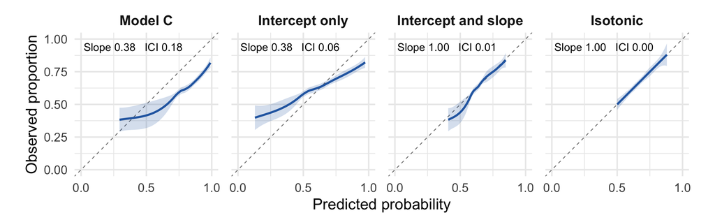

Intercept-only recalibration moves the curve but leaves it tilted. Adding the slope straightens it. Isotonic regression fits any increasing curve, and checked on the riders it was fitted to, it flatters itself.

## Beyond the formula

- **Isotonic regression**: the best increasing staircase through the data. No formula, so it needs many riders, and it can overfit
- **Model revision**: re-estimate the coefficients that are wrong. Model B’s superhero coefficient (2.5) points the wrong way; no shift or stretch can put Batman back in line
- **Refit**: build a new model
- **Which step?** Start at the bottom and climb only while the step below leaves miscalibration; check the result on fresh data

## Two vocabularies, one idea

| Biostatistics | Machine learning |
| --- | --- |
| Outcome | Label, target |
| Predictors | Features |
| Coefficient; intercept | Weight; bias |
| Logistic function (`plogis()`) | Sigmoid |
| c statistic, concordance | AUC, AUROC |
| Sensitivity | Recall, true positive rate |
| 1 − specificity | False positive rate |
| Positive predictive value | Precision |
| Somers’ D | Gini coefficient |
| Brier score | Mean squared error of probabilities |
| Log-likelihood (negative) | Log loss, cross-entropy |
| Logistic recalibration | Platt scaling |
| Development and validation data | Training and test data |

## Take-home points

1. **Discrimination** is about order: the c statistic counts correctly ranked pairs, which equals the area under the ROC curve
2. **Calibration** is about agreement: compare predicted with observed, on average (O/E) and across the range (calibration plot, ICI)
3. The **Brier score**, **F1** and **accuracy** blend both, so they cannot tell you which problem a model has
4. **Recalibration** can fix calibration but never discrimination: start with the intercept, and add the slope only if needed
5. **Time** matters for calibration, not discrimination: a late bus breaks calibration and leaves the ranking alone

## Try it yourself

```r
riders <- data.frame(
  rider     = c("Agnes", "Beatrice", "Clara", "Dorothy", "Batman"),
  age       = c(35, 80, 85, 80, 40),
  cane      = c(0, 0, 1, 0, 0),
  superhero = c(0, 0, 0, 0, 1),
  boarded   = c(0, 1, 1, 1, 0)
)
# Model A (see the slide "Two models")
riders$model_a <- with(riders, plogis(
  2.0 + 0.1 * (age - 60) / 10 + 1.0 * cane - 1.0 * superhero
))
p <- riders$model_a

# c statistic (ties count half)
pairs <- expand.grid(
  boarded = which(riders$boarded == 1),
  waited = which(riders$boarded == 0)
)
better <- p[pairs$boarded] > p[pairs$waited]
tied <- p[pairs$boarded] == p[pairs$waited]
mean(better + 0.5 * tied)

mean(riders$boarded) / mean(p) # O/E
mean((p - riders$boarded)^2)   # Brier score

# Recalibrate: shift the log-odds
fit <- glm(boarded ~ 1, offset = qlogis(model_a), family = binomial, data = riders)
plogis(qlogis(p) + coef(fit))
```